# Week 9

## OpenCage API

```python
oc_url = "https://api.opencagedata.com/geocode/v1/json"
```

```python
key = "65b1171691324bb68feac286a27a3460"
```

```python
params={"key": key,
        "q": "Buffalo, NY",
       }
```

```python
import requests

r = requests.get(oc_url, params=params)
```

```python
r.text[:1000]
```

```
'{"documentation":"https://opencagedata.com/api","licenses":[{"name":"see attribution guide","url":"https://opencagedata.com/credits"}],"rate":{"limit":2500,"remaining":2499,"reset":1649030400},"results":[{"annotations":{"DMS":{"lat":"42\\u00b0 53\' 12.17976\'\' N","lng":"78\\u00b0 52\' 42.21192\'\'…
```

```python
data = r.json()
data
```

```python
len(data["results"])
```

```
9
```

```python
data["results"][0]
```

```
{'annotations': {'DMS': {'lat': "42° 53' 12.17976'' N",
   'lng': "78° 52' 42.21192'' W"},
  'FIPS': {'county': '36029', 'state': '36'},
  'MGRS': '17TPH7324950418',
  'Maidenhead': 'FN02nv42ot',
  'Mercator': {'x': -8780702.454, 'y': 5265656.791},
  'OSM': {'edit_url': 'https://www.openstreetmap.org/edit?relation=175031#map=17/42.88672/-78.87839',
   'note_url': 'https://www.openstreetmap.org/note/new#map=17/42.88672/-78.87839&layers=N',
   'url': 'https://www.openstreetmap.org/?mlat=42.88672&mlon=-78.87839#map=17/42.88672/-78.87839'},
  'UN_M49': {'regions': {'AMERICAS': '019',
    'NORTHERN_AMERICA': '021',
    'US': '840',
    'WORLD': '001'},
   'statistical_groupings': ['MEDC']},
  'callingcode': 1,
  'currency': {'alternate_symbols': ['US$'],
   'decimal_mark': '.',
   'disambiguate_symbol': 'US$',
   'html_entity': '$',
   'iso_code': 'USD',
   'iso_numeric': '840',
   'name': 'United States Dollar',
   'smallest_denomination': 1,
   'subunit': 'Cent',
   'subunit_to_unit': 100,
   'symbol': '$',
   'symbol_first': 1,
   'thousands_separator': ','},
  'flag': '🇺🇸',
  'geohash': 'dpxgvp690prv6z8cs0en',
  'qibla': 54.99,
  'roadinfo': {'drive_on': 'right', 'speed_in': 'mph'},
  'sun': {'rise': {'apparent': 1648983300,
    'astronomical': 1648977420,
    'civil': 1648981560,
    'nautical': 1648979520},
   'set': {'apparent': 1649029380,
    'astronomical': 1648948920,
    'civil': 1648944720,
    'nautical': 1648946760}},
```

[output cut: 8 more lines]

```
  'southwest': {'lat': 42.826006, 'lng': -78.922357}},
 'components': {'ISO_3166-1_alpha-2': 'US',
  'ISO_3166-1_alpha-3': 'USA',
  '_category': 'place',
  '_type': 'city',
  'city': 'Buffalo',
  'continent': 'North America',
  'country': 'United States',
  'country_code': 'us',
  'county': 'Erie County',
  'state': 'New York',
  'state_code': 'NY'},
 'confidence': 6,
 'formatted': 'Buffalo, New York, United States of America',
 'geometry': {'lat': 42.8867166, 'lng': -78.8783922}}
```

```python
annot = data["results"][0]["annotations"]
annot
```

```
{'DMS': {'lat': "42° 53' 12.17976'' N", 'lng': "78° 52' 42.21192'' W"},
 'FIPS': {'county': '36029', 'state': '36'},
 'MGRS': '17TPH7324950418',
 'Maidenhead': 'FN02nv42ot',
 'Mercator': {'x': -8780702.454, 'y': 5265656.791},
 'OSM': {'edit_url': 'https://www.openstreetmap.org/edit?relation=175031#map=17/42.88672/-78.87839',
  'note_url': 'https://www.openstreetmap.org/note/new#map=17/42.88672/-78.87839&layers=N',
  'url': 'https://www.openstreetmap.org/?mlat=42.88672&mlon=-78.87839#map=17/42.88672/-78.87839'},
 'UN_M49': {'regions': {'AMERICAS': '019',
   'NORTHERN_AMERICA': '021',
   'US': '840',
   'WORLD': '001'},
  'statistical_groupings': ['MEDC']},
 'callingcode': 1,
 'currency': {'alternate_symbols': ['US$'],
  'decimal_mark': '.',
  'disambiguate_symbol': 'US$',
  'html_entity': '$',
  'iso_code': 'USD',
  'iso_numeric': '840',
  'name': 'United States Dollar',
  'smallest_denomination': 1,
  'subunit': 'Cent',
  'subunit_to_unit': 100,
  'symbol': '$',
  'symbol_first': 1,
  'thousands_separator': ','},
 'flag': '🇺🇸',
 'geohash': 'dpxgvp690prv6z8cs0en',
 'qibla': 54.99,
 'roadinfo': {'drive_on': 'right', 'speed_in': 'mph'},
 'sun': {'rise': {'apparent': 1648551780,
   'astronomical': 1648546020,
   'civil': 1648550100,
   'nautical': 1648548120},
  'set': {'apparent': 1648597080,
   'astronomical': 1648516500,
   'civil': 1648512360,
   'nautical': 1648514400}},
 'timezone': {'name': 'America/New_York',
  'now_in_dst': 1,
  'offset_sec': -14400,
  'offset_string': '-0400',
  'short_name': 'EDT'},
 'what3words': {'words': 'taking.youth.could'},
 'wikidata': 'Q40435'}
```

```python
print(annot["OSM"]["url"])
```

```
https://www.openstreetmap.org/?mlat=42.88672&mlon=-78.87839#map=17/42.88672/-78.87839
```

```python
sunset = annot["sun"]["set"]["apparent"]
sunset
```

```
1648597080
```

```python
from datetime import datetime

datetime.fromtimestamp(sunset)
```

```
datetime.datetime(2022, 3, 29, 19, 38)
```

```python
params={"key": key,
        "q": "Mathematics Building, University at Buffalo"
       }

ubmath = requests.get(oc_url, params=params).json()
```

```python
ubmath
```

```
{'documentation': 'https://opencagedata.com/api',
 'licenses': [{'name': 'see attribution guide',
   'url': 'https://opencagedata.com/credits'}],
 'rate': {'limit': 2500, 'remaining': 2497, 'reset': 1648425600},
 'results': [{'annotations': {'DMS': {'lat': "43° 0' 4.45860'' N",
     'lng': "78° 47' 34.04688'' W"},
    'FIPS': {'county': '36029', 'state': '36'},
    'MGRS': '17TPH7990563316',
    'Maidenhead': 'FN03oa40uh',
    'Mercator': {'x': -8771173.347, 'y': 5283009.654},
    'OSM': {'edit_url': 'https://www.openstreetmap.org/edit?way=641696374#map=17/43.00124/-78.79279',
     'note_url': 'https://www.openstreetmap.org/note/new#map=17/43.00124/-78.79279&layers=N',
     'url': 'https://www.openstreetmap.org/?mlat=43.00124&mlon=-78.79279#map=17/43.00124/-78.79279'},
    'UN_M49': {'regions': {'AMERICAS': '019',
      'NORTHERN_AMERICA': '021',
      'US': '840',
      'WORLD': '001'},
     'statistical_groupings': ['MEDC']},
    'callingcode': 1,
    'currency': {'alternate_symbols': ['US$'],
     'decimal_mark': '.',
     'disambiguate_symbol': 'US$',
     'html_entity': '$',
     'iso_code': 'USD',
     'iso_numeric': '840',
     'name': 'United States Dollar',
     'smallest_denomination': 1,
     'subunit': 'Cent',
     'subunit_to_unit': 100,
     'symbol': '$',
     'symbol_first': 1,
     'thousands_separator': ','},
    'flag': '🇺🇸',
    'geohash': 'dpxuxh0u6gufumu90zxr',
    'qibla': 55.05,
    'roadinfo': {'drive_on': 'right',
     'road': 'Mary Talbert Way',
     'speed_in': 'mph'},
    'sun': {'rise': {'apparent': 1648379220,
      'astronomical': 1648373400,
```

[output cut: 86 more lines]

```
    'country_code': 'us',
    'county': 'Erie County',
    'state': 'New York',
    'state_code': 'NY',
    'town': 'Buffalo'},
   'confidence': 6,
   'formatted': 'Buffalo, New York, United States of America',
   'geometry': {'lat': 42.88645, 'lng': -78.87837}}],
 'status': {'code': 200, 'message': 'OK'},
 'stay_informed': {'blog': 'https://blog.opencagedata.com',
  'twitter': 'https://twitter.com/OpenCage'},
 'thanks': 'For using an OpenCage API',
 'timestamp': {'created_http': 'Sun, 27 Mar 2022 17:02:48 GMT',
  'created_unix': 1648400568},
 'total_results': 2}
```

```python
print(ubmath["results"][0]["annotations"]["OSM"]["url"])
```

```
https://www.openstreetmap.org/?mlat=43.00124&mlon=-78.79279#map=17/43.00124/-78.79279
```

## JSON library

```python
import json

record = {'name': "Bob", "age": 21, "grades": ['A', 'B+'], 1: 100, 2:90, }
json.dumps(record)
```

```
'{"name": "Bob", "age": 21, "grades": ["A", "B+"], "1": 100, "2": 90}'
```

```python
with open("sample.json", "w") as f:
    json.dump(record, f)
```

```python
with open("sample.json") as f:
    x = json.load(f)

x
```

```
{'name': 'Bob', 'age': 21, 'grades': ['A', 'B+'], '1': 100, '2': 90}
```

## Project: Discord logs

```python
with open("discord_logs.json") as f:
    logs = json.load(f)
```

```python
logs
```

## Time operations

```python
from datetime import datetime
```

```python
d1 = '2021-03-04T21:52:22.618+00:00'
d2 = '2021-03-04T21:47:01.265+00:00'
```

```python
datetime.fromisoformat(d1)
```

```
datetime.datetime(2021, 3, 4, 21, 52, 22, 618000, tzinfo=datetime.timezone.utc)
```

```python
date1 = datetime.fromisoformat(d1).astimezone()
date1
```

```
datetime.datetime(2021, 3, 4, 16, 52, 22, 618000, tzinfo=datetime.timezone(datetime.timedelta(days=-1, seconds=68400), 'EST'))
```

```python
print(date1.year)
print(date1.month)
print(date1.hour)
print(date1.minute)
print(date1.second)
print(date1.weekday())
```

```
2021
3
16
52
22
3
```

```python
date1.strftime("%A %m/%d/%Y, %I:%m %p")
```

```
'Thursday 03/04/2021, 04:03 PM'
```

```python
date2 = datetime.fromisoformat(d2).astimezone()
date2
```

```
datetime.datetime(2021, 3, 4, 16, 47, 1, 265000, tzinfo=datetime.timezone(datetime.timedelta(days=-1, seconds=68400), 'EST'))
```

```python
delta = date1 - date2
delta
```

```
datetime.timedelta(seconds=321, microseconds=353000)
```

```python
delta.total_seconds()
```

```
321.353
```

```python
minutes = delta.seconds/60
minutes
```

```
5.35
```

### Time values in Pandas

From the course website:

```python
import pandas as pd

df = pd.DataFrame([
    {
        "event": "event_1",
        "start": '2021-03-04T23:03:12.351+00:00',
        "end": '2021-03-04T23:04:08.669+00:00'
    },
    {
        "event": "event_2",
        "start": '2021-03-05T12:12:12.010+00:00',
        "end": '2021-03-05T17:56:17.123+00:00'
    },
    {
        "event": "event_3",
        "start": '2021-03-04T13:29:45.594+00:00',
        "end": '2021-03-06T00:04:46.032+00:00'
    },
])

df
```

|  | event | start | end |
| --- | --- | --- | --- |
| 0 | event_1 | 2021-03-04T23:03:12.351+00:00 | 2021-03-04T23:04:08.669+00:00 |
| 1 | event_2 | 2021-03-05T12:12:12.010+00:00 | 2021-03-05T17:56:17.123+00:00 |
| 2 | event_3 | 2021-03-04T13:29:45.594+00:00 | 2021-03-06T00:04:46.032+00:00 |

```python
df.info()
```

```
<class 'pandas.core.frame.DataFrame'>
RangeIndex: 3 entries, 0 to 2
Data columns (total 3 columns):
 #   Column  Non-Null Count  Dtype
---  ------  --------------  -----
 0   event   3 non-null      object
 1   start   3 non-null      object
 2   end     3 non-null      object
dtypes: object(3)
memory usage: 200.0+ bytes
```

```python
df['start'] = pd.to_datetime(df['start']).dt.tz_convert("America/New_York")
df['end'] = pd.to_datetime(df['end']).dt.tz_convert("America/New_York")
df
```

|  | event | start | end |
| --- | --- | --- | --- |
| 0 | event_1 | 2021-03-04 18:03:12.351000-05:00 | 2021-03-04 18:04:08.669000-05:00 |
| 1 | event_2 | 2021-03-05 07:12:12.010000-05:00 | 2021-03-05 12:56:17.123000-05:00 |
| 2 | event_3 | 2021-03-04 08:29:45.594000-05:00 | 2021-03-05 19:04:46.032000-05:00 |

```python
import pytz
pytz.all_timezones[:10]
```

```
['Africa/Abidjan',
 'Africa/Accra',
 'Africa/Addis_Ababa',
 'Africa/Algiers',
 'Africa/Asmara',
 'Africa/Asmera',
 'Africa/Bamako',
 'Africa/Bangui',
 'Africa/Banjul',
 'Africa/Bissau']
```

```python
df.info()
```

```
<class 'pandas.core.frame.DataFrame'>
RangeIndex: 3 entries, 0 to 2
Data columns (total 3 columns):
 #   Column  Non-Null Count  Dtype
---  ------  --------------  -----
 0   event   3 non-null      object
 1   start   3 non-null      datetime64[ns, America/New_York]
 2   end     3 non-null      datetime64[ns, America/New_York]
dtypes: datetime64[ns, America/New_York](2), object(1)
memory usage: 200.0+ bytes
```

```python
df["duration"] = df["end"] - df["start"]
df
```

|  | event | start | end | duration |
| --- | --- | --- | --- | --- |
| 0 | event_1 | 2021-03-04 18:03:12.351000-05:00 | 2021-03-04 18:04:08.669000-05:00 | 0 days 00:00:56.318000 |
| 1 | event_2 | 2021-03-05 07:12:12.010000-05:00 | 2021-03-05 12:56:17.123000-05:00 | 0 days 05:44:05.113000 |
| 2 | event_3 | 2021-03-04 08:29:45.594000-05:00 | 2021-03-05 19:04:46.032000-05:00 | 1 days 10:35:00.438000 |

```python
df.info()
```

```
<class 'pandas.core.frame.DataFrame'>
RangeIndex: 3 entries, 0 to 2
Data columns (total 4 columns):
 #   Column    Non-Null Count  Dtype
---  ------    --------------  -----
 0   event     3 non-null      object
 1   start     3 non-null      datetime64[ns, America/New_York]
 2   end       3 non-null      datetime64[ns, America/New_York]
 3   duration  3 non-null      timedelta64[ns]
dtypes: datetime64[ns, America/New_York](2), object(1), timedelta64[ns](1)
memory usage: 224.0+ bytes
```

```python
df["duration"].dt.total_seconds()
```

```
0        56.318
1     20645.113
2    124500.438
Name: duration, dtype: float64
```

## Marathon data

```python
import pandas as pd

df = pd.read_csv('marathon_results.csv')
df.sample(5)
```

|  | Age | M/F | Country | 5K | 10K | 15K | 20K | Half | 25K | 30K | 35K | 40K | Finish | Pace | Overall | Gender | Division |
| --- | --- | --- | --- | --- | --- | --- | --- | --- | --- | --- | --- | --- | --- | --- | --- | --- | --- |
| 5714 | 46 | M | SWE | 00:22:59 | 00:45:10 | 01:07:24 | 01:29:55 | 01:34:56 | 01:52:38 | 02:16:32 | 02:40:40 | 03:04:29 | 03:14:40 | 00:07:26 | 5728 | 5059 | 651 |
| 17769 | 50 | F | USA | 00:26:14 | 00:52:23 | 01:19:07 | 01:46:38 | 01:52:36 | 02:14:10 | 02:43:31 | 03:13:46 | 03:42:27 | 03:55:35 | 00:09:00 | 17894 | 7021 | 502 |
| 24569 | 44 | F | USA | 00:34:04 | 01:08:32 | 01:44:27 | 02:18:19 | 02:25:30 | 02:53:09 | 03:29:08 | 04:07:08 | 04:42:03 | 04:57:33 | 00:11:21 | 24813 | 11004 | 1847 |
| 8958 | 44 | F | USA | 00:24:03 | 00:47:49 | 01:11:54 | 01:36:09 | 01:41:24 | 02:00:30 | 02:25:05 | 02:50:35 | 03:15:30 | 03:26:39 | 00:07:53 | 8984 | 1869 | 210 |
| 7367 | 28 | F | USA | 00:23:56 | 00:47:16 | 01:10:22 | 01:33:46 | 01:38:51 | 01:57:00 | 02:20:57 | 02:45:38 | 03:10:18 | 03:21:30 | 00:07:42 | 7383 | 1204 | 1007 |

```python
pd.to_timedelta(df["Finish"]).dt.total_seconds()
```

```
0         7757.0
1         7788.0
2         7822.0
3         7847.0
4         7849.0
          ...
26293    27536.0
26294    28290.0
26295    28773.0
26296    28837.0
26297    29161.0
Name: Finish, Length: 26298, dtype: float64
```

```python
df["tot_minutes"] = pd.to_timedelta(df["Finish"]).dt.total_seconds()/60
df.sample(3)
```

|  | Age | M/F | Country | 5K | 10K | 15K | 20K | Half | 25K | 30K | 35K | 40K | Finish | Pace | Overall | Gender | Division | tot_minutes |
| --- | --- | --- | --- | --- | --- | --- | --- | --- | --- | --- | --- | --- | --- | --- | --- | --- | --- | --- |
| 4227 | 47 | M | JPN | 00:21:09 | 00:41:45 | 01:02:36 | 01:23:49 | 01:28:27 | 01:45:19 | 02:07:52 | 02:32:06 | 02:56:50 | 03:08:09 | 00:07:11 | 4237 | 3899 | 373 | 188.150000 |
| 1130 | 43 | M | USA | 00:20:58 | 00:41:17 | 01:01:17 | 01:21:37 | 01:25:59 | 01:41:43 | 02:02:14 | 02:22:30 | 02:42:31 | 02:51:52 | 00:06:34 | 1132 | 1086 | 114 | 171.866667 |
| 15638 | 38 | F | USA | 00:26:02 | 00:50:41 | 01:14:57 | 01:40:59 | 01:46:29 | 02:08:00 | 02:36:57 | 03:05:52 | 03:36:02 | 03:47:52 | 00:08:42 | 15729 | 5671 | 3626 | 227.866667 |

Histogram of finish times:

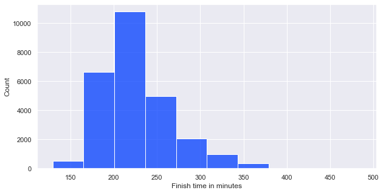

```python
import seaborn as sns
import matplotlib.pyplot as plt

plt.figure(figsize=(10, 5))
sns.set_theme(style="darkgrid", palette="bright")
a = sns.histplot(df["tot_minutes"],bins = 10)
plt.xlabel("Finish time in minutes");
```

```python
import numpy as np
np.histogram(df["tot_minutes"], bins=10)
```

```
(array([  499,  6647, 10789,  4978,  2068,   969,   332,     8,     3,
            5]),
 array([129.28333333, 164.95666667, 200.63      , 236.30333333,
        271.97666667, 307.65      , 343.32333333, 378.99666667,
        414.67      , 450.34333333, 486.01666667]))
```

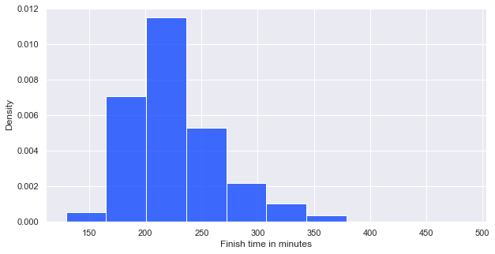

```python
import seaborn as sns
import matplotlib.pyplot as plt

plt.figure(figsize=(10, 5))
sns.set_theme(style="darkgrid", palette="bright")
a = sns.histplot(df["tot_minutes"],bins = 10, stat="density")
plt.xlabel("Finish time in minutes");
```

## Dependence of a histogram on bin width and bin endpoint selection

From the course website:

```python
import numpy as np
import seaborn as sns
import matplotlib.pyplot as plt
from ipywidgets import interact, fixed

%config InlineBackend.figure_format = 'retina'
sns.set_theme(style="darkgrid", palette="bright")

def hist(data, bins=10, shift=0):
    '''
    Plots a histogram of data.

    bins:
        number of bins
    shift:
        shift of bin boundaries.
    '''

    plt.figure(figsize=(12,4))
    max_shift = 5
    data = np.array(data)
    plt.xlim(data.min() - max_shift, data.max() + max_shift)
    sns.histplot(data,
                 stat="density",
                 bins=bins,
                 binrange =  (data.min() - max_shift + shift,
                               data.max() + max_shift + shift)
                )
    sns.rugplot(data, height=0.05, color='w')
    plt.show()


N = 50
rng = np.random.default_rng(10)
data = rng.normal(loc=10, scale=5, size=N)
interact(hist, shift=(0, 5, 0.25), bins=(1, 30, 1), data=fixed(data));
```

```
interactive(children=(IntSlider(value=10, description='bins', max=30, min=1), FloatSlider(value=0.0, descripti…
```

## Probability density functions

$$P(a< x < b) = \int_a^b f(x) dx$$

### Gaussian kernel

$$f(x) = \frac{1}{h\sqrt{2\pi}}\exp\left(-\frac{1}{2}\left(\frac{x-X}{h}\right)^2\right)$$

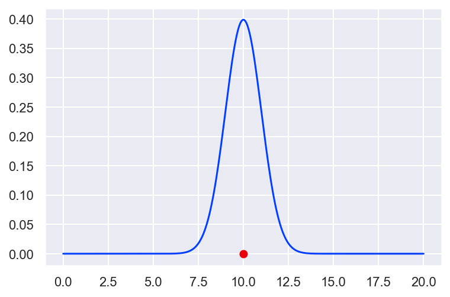

```python
from scipy.stats import norm

h = 1
X = 10
x = np.linspace(0, 20, 300)
plt.plot(x, norm.pdf(x, loc=X, scale=h));
plt.plot(X, 0, 'ro')
plt.show()
```

## KDE with Gaussian kernel

From the course website:

```python
from scipy.stats import norm

def kde(data, h, x):
    """
    Compute KDE of data with  Gaussian kernels

    x:
       KDE value will be computed for each value
       of this array.
    h:
       Kernel bandwidth
    """

    y = np.zeros_like(x)
    for X in data:
        y += norm.pdf(x, loc=X, scale=h)
    return y/len(data)


def plot_kde(data, h=0.1, show_kernels=False):
    """
    Plot KDE

    data:
        An array with data defining KDE.
    h:
        Kernel bandwidth.
    show_kernels:
        Boolean. If true, individual kernels are
        plotted too.
    """

    x = np.linspace(data.min() - 3, data.max() + 3, 400)
    plt.figure(figsize=(14,4))
    plt.plot(x, kde(data, h, x), lw=7, c='steelblue', alpha=0.4)
    plt.plot(data, [0]*len(data), 'r|', ms=15, mew=2)
    if show_kernels:
        for X in data:
            plt.plot(x, 1/len(data)*norm.pdf(x, loc=X, scale=h), 'r--', lw=0.7)
```

Plot KDE for sample data:

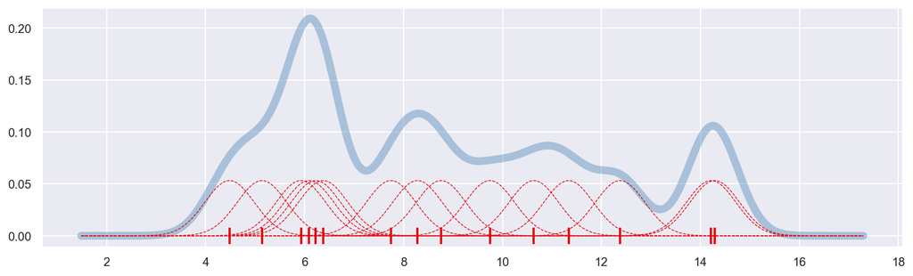

```python
N = 15
rng = np.random.default_rng(10)
data = rng.normal(loc=10, scale=5, size=N)

plot_kde(data, h=0.5, show_kernels=True)
```

Widget showing dependence of KDE on bandwidth selection:

```python
interact(plot_kde, data = fixed(data), h=(0.1, 4, 0.1), show_kernels=True);
```

```
interactive(children=(FloatSlider(value=0.1, description='h', max=4.0, min=0.1), Checkbox(value=True, descript…
```

### Gaussian KDE with SciPy.

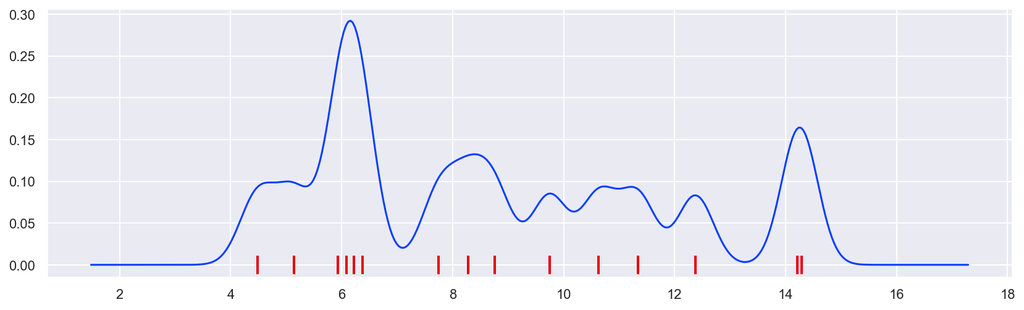

```python
from  scipy.stats import gaussian_kde

kde = gaussian_kde(data, bw_method=0.1)

plt.figure(figsize=(14,4))
plt.plot(data, [0]*len(data), 'r|', ms=15, mew=2)
x = np.linspace(data.min() - 3, data.max() + 3, 400)
plt.plot(x, kde(x));
```

```python
0.1*data.std()
```

```
0.31031375908978825
```

**Note.** `scipy.stats.gaussian_kde` by default uses Scott's rule to select bandwidth: $$h = n^{-1/5}\cdot\sigma$$ where $n$ is the number of points in the sample, and $\sigma$ is the standard deviation of the sample.

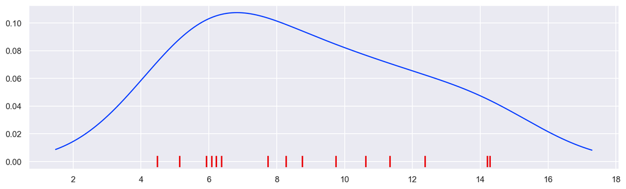

```python
kde = gaussian_kde(data)

plt.figure(figsize=(14,4))
x = np.linspace(data.min() - 3, data.max() + 3, 400)
plt.plot(x, kde(x))
plt.plot(data, [0]*len(data), 'r|', ms=15, mew=2);
```

Compute integral of KDE in a given range:

```python
kde.integrate_box(5, 10)
```

```
0.4903819181738276
```

From the course website:

```python
from ipywidgets import interact, fixed, FloatSlider
from  scipy.stats import gaussian_kde

def integrate(data, lower=7, upper=12):
    """
    Plot integral of KDE

    data:
        An array with data defining KDE
    lower, upper:
        Limits of integration.
    """

    kde_data = gaussian_kde(data)
    integral = kde_data.integrate_box(lower, upper)
    xfill = np.linspace(lower, upper, 100)

    x_min = data.min() - 1
    x_max = data.max() + 1
    x = np.linspace(x_min, x_max, 400)

    plt.figure(figsize=(10, 5))
    plt.xlim(x_min - 1, x_max + 1)
    plt.title(f"$\int^{{{upper:.2f}}}_{{{lower:.2f}}}\ f(t)dt = {integral:.3f}$",
              fontsize=20,
              y=1.1)
    plt.plot(x, kde_data(x))
    if lower <= upper:
        plt.fill_between(xfill,
                         kde_data(xfill),
                         0,
                         color='steelblue',
                         alpha=0.3)
    plt.plot(data, [0] * len(data), 'r|', ms=15)


N = 50
rng = np.random.default_rng(10)
data = rng.normal(loc=10, scale=5, size=N)
interact(integrate,
         data=fixed(data),
         lower=FloatSlider(min=data.min() - 1,
                           max=data.max() + 1,
                           step=0.2,
                           continuous_update=False),
         upper=FloatSlider(min=data.min() - 1,
                           max=data.max() + 1,
                           step=0.2,
                           continuous_update=False));
```

```
interactive(children=(FloatSlider(value=0.0, continuous_update=False, description='lower', max=18.711520554978…
```

## KDE for marathon finish times

KDE of finish times for all marathon runners:

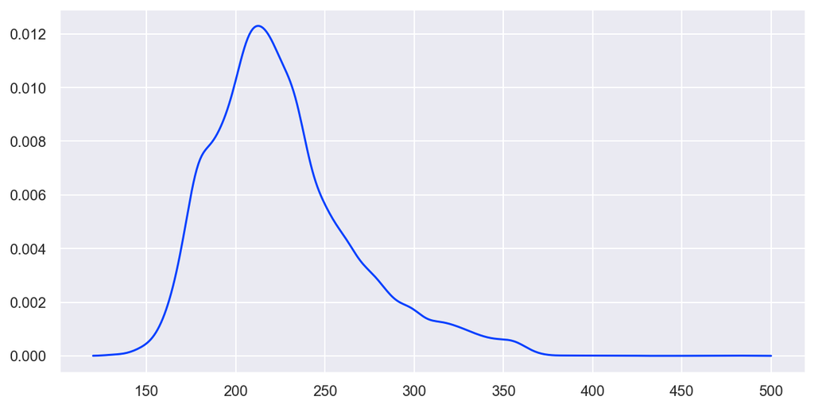

```python
kde = gaussian_kde(df["tot_minutes"])
plt.figure(figsize=(10,5))
x = np.linspace(120, 500, 400)
plt.plot(x, kde(x));
```

```python
kde(200)
```

```
array([0.01028678])
```

Probability that a runner finished in between 3 and 4 hours:

```python
kde.integrate_box(180, 240)
```

```
0.6080317849552407
```

### Guessing sex based on finish time

Split data by sex, and compute KDE for each group:

```python
dfm = df[df["M/F"] == "M"]
dff = df[df["M/F"] == "F"]

kdem = gaussian_kde(dfm["tot_minutes"])
kdef = gaussian_kde(dff["tot_minutes"])
```

Plot density functions:

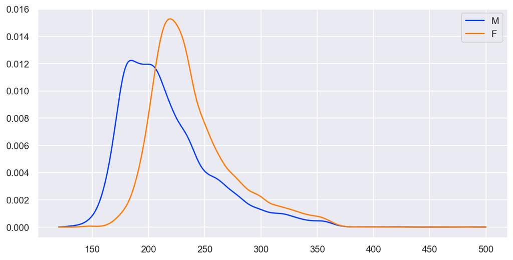

```python
x = np.linspace(120,500, 400)
plt.figure(figsize=(10,5))
plt.plot(x, kdem(x), label="M")
plt.plot(x, kdef(x), label="F")
plt.legend()
plt.show()
```

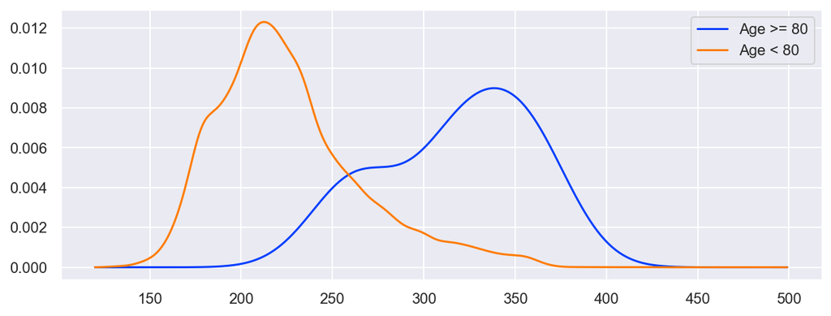

```python
gt80 = df[df["Age"] >= 80]
lt80 = df[df["Age"] < 80]


kde_gt80 = gaussian_kde(gt80["tot_minutes"])
kde_lt80 = gaussian_kde(lt80["tot_minutes"])

x2 = np.r_[120:500]
plt.figure(figsize=(10,8))
plt.subplot(211)
plt.plot(x2, kde_gt80(x2), label=f"Age >= 80")
plt.plot(x2, kde_lt80(x2), label=f"Age < 80")
plt.legend()
plt.show()
```

```python
gt80
```

|  | Age | M/F | Country | 5K | 10K | 15K | 20K | Half | 25K | 30K | 35K | 40K | Finish | Pace | Overall | Gender | Division | tot_minutes |
| --- | --- | --- | --- | --- | --- | --- | --- | --- | --- | --- | --- | --- | --- | --- | --- | --- | --- | --- |
| 21445 | 82 | M | USA | 00:28:17 | 00:56:47 | 01:25:21 | 01:55:29 | 02:02:04 | 02:26:15 | 02:58:08 | 03:31:53 | 04:04:23 | 04:18:00 | 00:09:51 | 21626 | 12387 | 1 | 258.000000 |
| 22075 | 80 | M | USA | 00:28:01 | 00:54:50 | 01:21:32 | 01:50:24 | 01:56:26 | 02:18:29 | 02:49:29 | 03:24:29 | 04:05:33 | 04:23:13 | 00:10:03 | 22268 | 12682 | 2 | 263.216667 |
| 22448 | 81 | M | USA | 00:28:56 | 00:58:11 | 01:28:20 | 01:59:24 | 02:06:14 | 02:31:07 | 03:04:02 | 03:37:42 | 04:11:24 | 04:26:49 | 00:10:11 | 22646 | 12841 | 3 | 266.816667 |
| 25189 | 80 | M | USA | 00:34:57 | 01:13:19 | 01:49:37 | 02:27:17 | 02:35:20 | 03:05:29 | 03:43:12 | 04:22:43 | 04:58:14 | 05:13:37 | 00:11:58 | 25446 | 14072 | 4 | 313.616667 |
| 25422 | 81 | M | USA | 00:35:35 | 01:12:16 | 01:48:45 | 02:26:31 | 02:34:48 | 03:04:55 | 03:44:07 | 04:23:28 | 05:03:44 | 05:20:49 | 00:12:15 | 25686 | 14185 | 5 | 320.816667 |
| 25428 | 82 | M | USA | 00:33:32 | 01:07:54 | 01:43:43 | 02:20:34 | 02:29:08 | 02:59:01 | 03:38:37 | 04:21:04 | 05:02:35 | 05:20:55 | 00:12:15 | 25692 | 14188 | 6 | 320.916667 |
| 25574 | 80 | M | USA | 00:31:50 | 01:06:35 | 01:44:29 | 02:25:14 | 02:32:52 | 03:03:07 | 03:47:42 | 04:29:57 | 05:08:14 | 05:25:57 | 00:12:26 | 25843 | 14258 | 7 | 325.950000 |
| 26119 | 82 | F | USA | 00:36:54 | 01:14:34 | 01:54:54 | 02:36:39 | 02:45:42 | 03:18:39 | 04:04:44 | 04:49:32 | 05:33:24 | 05:53:40 | 00:13:30 | 26411 | 11923 | 1 | 353.666667 |
| 26168 | 80 | M | USA | 00:33:33 | 01:07:16 | 01:41:45 | 02:16:24 | 02:23:47 | 02:53:16 | 03:39:35 | 04:36:43 | 05:33:05 | 05:56:24 | 00:13:36 | 26461 | 14512 | 8 | 356.400000 |
| 26193 | 82 | M | USA | 00:36:38 | 01:14:17 | 01:53:57 | 02:36:49 | 02:46:08 | 03:19:46 | 04:05:06 | 04:51:33 | 05:38:06 | 05:57:54 | 00:13:40 | 26488 | 14527 | 9 | 357.900000 |
| 26217 | 80 | M | JPN | 00:37:01 | 01:15:09 | 01:57:08 | 02:42:08 | 02:50:42 | 03:25:09 | 04:08:30 | 04:55:05 | 05:39:59 | 05:59:54 | 00:13:44 | 26512 | 14539 | 10 | 359.900000 |

```python
len(df[(df["tot_minutes"] > 300) & (df["tot_minutes"] < 360)])
```

```
1519
```

## Predicting sex based on finish time.

**Goal:** Use KDE to predict sex of a runner based on the finish time.

We will use the Bayesian classifier:

- Given a runner with finish time $t_0$ estimate $P(\text{sex} = M | \text{ time} = t_0)$ and $P(\text{sex} = F | \text{ time} = t_0)$, and classify the runner based on which probability is larger.
- Problem: KDE lets us estimate probabilities $P( \text{ time} = t_0 | \text{ sex} = M )$ and $P( \text{ time} = t_0 | \text{ sex} = F )$.
- Solution: Use Bayes theorem: $$P(A|B) = \dfrac{P(B|A)\cdot P(A)}{P(B)}$$

In our case we obtain:

$$ P(\text{sex} = F | \text{ time} = t_0) = \dfrac{P( \text{ time} = t_0 | \text{ sex} = F)P(\text{ sex} = F)} {P( \text{ time} = t_0)} $$

Also: $$ P( \text{ time} = t_0) = P( \text{ time} = t_0 | \text{ sex} = F)P(\text{ sex} = F) + P( \text{ time} = t_0 | \text{ sex} = M)P(\text{ sex} = M) $$

Split marathon data into training and test parts:

```python
train_frac = 0.5

train_df = df.sample(frac=train_frac).copy()
train_df = train_df.sort_index()
train_df.head(5)
```

|  | Age | M/F | Country | 5K | 10K | 15K | 20K | Half | 25K | 30K | 35K | 40K | Finish | Pace | Overall | Gender | Division | tot_minutes |
| --- | --- | --- | --- | --- | --- | --- | --- | --- | --- | --- | --- | --- | --- | --- | --- | --- | --- | --- |
| 0 | 25 | M | ETH | 00:14:43 | 00:29:43 | 00:44:57 | 01:00:29 | 01:04:02 | 01:16:07 | 01:32:00 | 01:47:59 | 02:02:39 | 02:09:17 | 00:04:56 | 1 | 1 | 1 | 129.283333 |
| 2 | 29 | M | KEN | 00:14:43 | 00:29:43 | 00:44:57 | 01:00:29 | 01:04:02 | 01:16:07 | 01:32:00 | 01:47:59 | 02:03:01 | 02:10:22 | 00:04:59 | 3 | 3 | 3 | 130.366667 |
| 3 | 28 | M | KEN | 00:14:43 | 00:29:44 | 00:45:01 | 01:00:29 | 01:04:02 | 01:16:07 | 01:32:00 | 01:48:03 | 02:03:47 | 02:10:47 | 00:05:00 | 4 | 4 | 4 | 130.783333 |
| 4 | 32 | M | KEN | 00:14:43 | 00:29:44 | 00:44:58 | 01:00:28 | 01:04:01 | 01:16:07 | 01:32:00 | 01:47:59 | 02:03:27 | 02:10:49 | 00:05:00 | 5 | 5 | 5 | 130.816667 |
| 6 | 32 | M | USA | 00:14:45 | 00:29:45 | 00:45:20 | 01:00:43 | 01:04:03 | 01:16:05 | 01:31:59 | 01:48:06 | 02:04:05 | 02:11:20 | 00:05:01 | 7 | 7 | 7 | 131.333333 |

```python
test_df = df.drop(train_df.index).copy()
test_df.head(5)
```

[output not shown]

Next, we construct a predictor using training data. The `bw_method` argument can be used to check how predictions will change based the choice of KDE bandwidth.

```python
train_df_grouped = train_df.groupby("M/F")
train_dfm = train_df_grouped.get_group("M")
train_dff = train_df_grouped.get_group("F")

# kde for males
kdem = gaussian_kde(train_dfm["tot_minutes"])
# kde for females
kdef = gaussian_kde(train_dff["tot_minutes"])

# number of males
mc = train_dfm["tot_minutes"].count()

#number of females
fc = train_dff["tot_minutes"].count()

# probability runner is a female
prob_f = fc/(fc+mc)

# probability runner is a male
prob_m = mc/(fc+mc)

def predictor(t):
    ptf = kdef(t)
    ptm = kdem(t)
    return (kdef(t)*prob_f)/(kdef(t)*prob_f + kdem(t)*prob_m)
```

```python
predictor(240)
```

```
array([0.60281488])
```

Plot finish times vs predicted values:

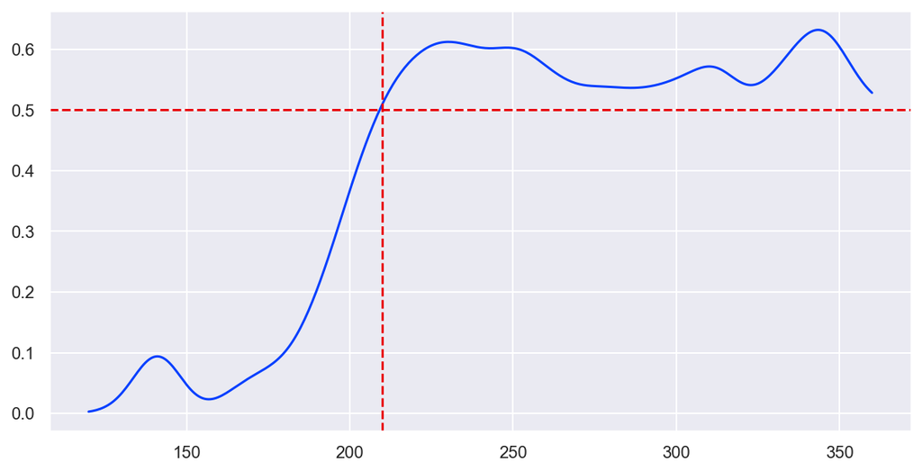

```python
t = np.linspace(120,360, 400)
plt.figure(figsize=(10,5))
plt.plot(t, predictor(t))
plt.axhline(0.5, ls ='--', c='r');
plt.axvline(210, ls ='--', c='r');
```

Add a column with predictions to the test DataFrame:

```python
test_df["prob_F"] = predictor(test_df["tot_minutes"])
test_df.sample(5)
```

|  | Age | M/F | Country | 5K | 10K | 15K | 20K | Half | 25K | 30K | 35K | 40K | Finish | Pace | Overall | Gender | Division | tot_minutes | prob_F |
| --- | --- | --- | --- | --- | --- | --- | --- | --- | --- | --- | --- | --- | --- | --- | --- | --- | --- | --- | --- |
| 13609 | 27 | F | USA | 00:21:49 | 00:43:47 | 01:06:21 | 01:29:35 | 01:34:35 | 01:55:52 | 02:22:42 | 02:54:03 | 03:26:08 | 03:40:44 | 00:08:26 | 13673 | 4414 | 3129 | 220.733333 | 0.591187 |
| 23757 | 60 | F | USA | 00:32:20 | 01:03:17 | 01:35:51 | 02:08:44 | 02:15:42 | 02:42:40 | 03:17:50 | 03:53:50 | 04:28:15 | 04:42:43 | 00:10:47 | 23980 | 10529 | 210 | 282.716667 | 0.536926 |
| 20198 | 56 | F | USA | 00:27:29 | 00:56:20 | 01:25:33 | 01:54:34 | 02:00:46 | 02:23:55 | 02:54:29 | 03:26:05 | 03:55:49 | 04:08:53 | 00:09:30 | 20353 | 8469 | 289 | 248.883333 | 0.602492 |
| 9697 | 60 | M | USA | 00:24:18 | 00:48:39 | 01:13:04 | 01:37:27 | 01:42:44 | 02:01:43 | 02:26:19 | 02:52:02 | 03:17:58 | 03:28:49 | 00:07:58 | 9726 | 7519 | 57 | 208.816667 | 0.495971 |
| 8214 | 54 | M | JPN | 00:23:26 | 00:46:36 | 01:09:58 | 01:33:31 | 01:38:39 | 01:57:30 | 02:22:55 | 02:48:45 | 03:13:13 | 03:24:10 | 00:07:48 | 8234 | 6702 | 610 | 204.166667 | 0.433248 |

Check prediction accuracy:

```python
sum((test_df["prob_F"] > 0.5) == (test_df["M/F"] == "F"))/len(test_df)
```

```
0.6534337211955282
```

We can predict with high confidence that some runners are men, but such prediction is not possible for women:

```python
test_df.query("prob_F < 0.3")["M/F"].value_counts()
```

```
M    2563
F     382
Name: M/F, dtype: int64
```

```python
test_df.query("prob_F > 0.7")["M/F"].value_counts()
```

```
Series([], Name: M/F, dtype: int64)
```

```python
test_df.query("prob_F < 0.3")["tot_minutes"].describe()
```

```
count    2945.000000
mean      180.836859
std        12.863717
min       129.283333
25%       174.483333
50%       181.716667
75%       189.300000
max       479.550000
Name: tot_minutes, dtype: float64
```

Compare with prediction accuracy of k-NN:

```python
from sklearn.neighbors import KNeighborsClassifier

k = 10

neigh = KNeighborsClassifier(n_neighbors=k)
neigh.fit(train_df["tot_minutes"].values.reshape(-1, 1), train_df["M/F"])

knn_pred = neigh.predict(test_df["tot_minutes"].values.reshape(-1, 1))

knn_pred
```

```
array(['M', 'M', 'M', ..., 'M', 'M', 'M'], dtype=object)
```

```python
print((knn_pred == test_df['M/F']).sum()/len(test_df))
```

```
0.6202753061069283
```

```python
neigh.predict_proba([[200]])
```

```
array([[0.2, 0.8]])
```

The plot below shows classification probabilities using KNN with a given number of neighbors:

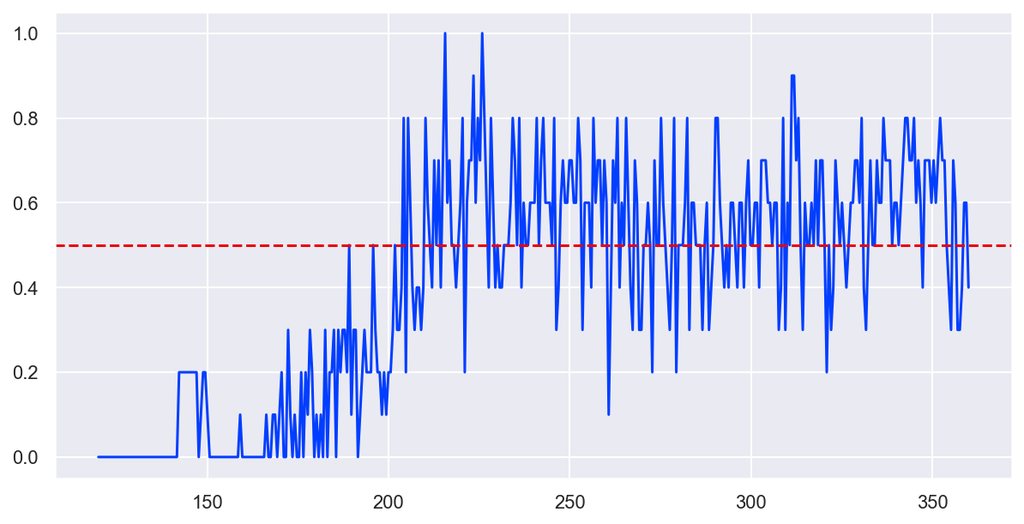

```python
plt.figure(figsize=(10,5))

x = np.linspace(120,360, 400).reshape(-1, 1)
plt.plot(x, neigh.predict_proba(x)[:, 0])
plt.axhline(0.5, ls ='--', c='r');
plt.show()
```